# linear

2022-12-08

```r
library(tidyverse)
library(dplyr)
library(rvest)
library(purrr)
library(ggplot2)
library(modelr)
library(mgcv)
library(patchwork)
library(viridis)
library(fastDummies)
set.seed(1)
```

1. Import original dataset
2. Remove repeated data

```r
childcare_inspection_df = read_csv("./data/DOHMH_Childcare_Center_Inspections.csv") %>%
janitor::clean_names() %>%
distinct()
```

Basic data cleaning

1. We select 22 key variables in this dataset to finish our analysis
2. Drop NA
3. Create a new variable “educational_worker_ratio”
4. Make all data in “program_type” and “facility_type” columns show in the same format : lower case

```r
childcare_inspection_df = childcare_inspection_df %>%
  select(center_name, borough, zip_code, status, age_range, maximum_capacity,program_type, facility_type,
         child_care_type, violation_category,
         violation_status,violation_rate_percent:average_critical_violation_rate,regulation_summary,
         inspection_summary_result) %>%
  drop_na(zip_code, age_range, violation_rate_percent,public_health_hazard_violation_rate, critical_violation_rate) %>%
  filter(maximum_capacity != 0) %>%
  mutate(
    educational_worker_ratio = total_educational_workers/maximum_capacity,
    program_type = tolower(program_type),
    facility_type = tolower(facility_type),
    borough =  as.factor(borough),
    status = as.factor(status),
    program_type = as.factor(program_type),
    facility_type = as.factor(facility_type),
    child_care_type = as.factor(child_care_type),
    age_range = as.factor(age_range)
  )
```

### Linear regression model

*Model selection:*

To explore the possible predictors contributing to the center-specific violation rate under each program type, we built a linear regression model. In this model, we focused on the violation rate and properties of each individual center.

To start with, we created a new variable named “rate”, which represents the violation rate for each center, by using violation category column. Here, rate = number of total violation for each center and program / number of total inspection for each center and program, during the past 3 year. This variable was used as the outcome of the linear regression.

```r
center_specific_df = childcare_inspection_df %>%
  relocate(center_name, program_type) %>%
  group_by(center_name, program_type) %>%
  mutate(
    n_na = sum(is.na(violation_category)),
    n_violation = sum(!is.na(violation_category)),
    rate = n_violation/(n_violation + n_na)) %>%
  arrange(center_name, program_type)
```

Next, we selected several variables closely related to the properties of each center, as the potential predictors. After a thorough literature review, we chose variables based on a hypothesized structure for the factors underlying violation rate.

Linear model 1:

First, we fit a full model using program type, borough, status, educational worker ratio of center-specific distinct records.

```r
# select distinct records and related variables of each center
center_distinct_df = center_specific_df %>%
  select(center_name, program_type, borough, status, maximum_capacity, total_educational_workers, educational_worker_ratio, rate)

# fit the full model
full_lm = center_distinct_df %>%
 lm(rate ~ program_type + borough + status + educational_worker_ratio, data = .)

full_lm %>%
  broom::tidy() %>%
  knitr::kable(digit = 3)
```

| term | estimate | std.error | statistic | p.value |
| --- | --- | --- | --- | --- |
| (Intercept) | 0.864 | 0.015 | 57.360 | 0.000 |
| program_typeinfant toddler | -0.028 | 0.011 | -2.422 | 0.015 |
| program_typepreschool | -0.004 | 0.009 | -0.442 | 0.658 |
| program_typeschool age camp | 0.116 | 0.141 | 0.823 | 0.410 |
| boroughBROOKLYN | -0.244 | 0.006 | -42.772 | 0.000 |
| boroughMANHATTAN | -0.186 | 0.006 | -30.276 | 0.000 |
| boroughQUEENS | -0.104 | 0.006 | -17.263 | 0.000 |
| boroughSTATEN ISLAND | -0.323 | 0.010 | -32.242 | 0.000 |
| statusExpired-In Renewal | -0.190 | 0.012 | -15.799 | 0.000 |
| statusPermitted | -0.239 | 0.011 | -21.115 | 0.000 |
| educational_worker_ratio | -0.083 | 0.015 | -5.346 | 0.000 |

Linear model 2:

Second, we also proposed an alternative model by using maximum_capacity, total educational workers and their interaction term as the predictors, instead of the educational worker ratio.

```r
# fit an alternative model
alt_lm = center_distinct_df %>%
 lm(rate ~ program_type + borough + status + maximum_capacity * total_educational_workers, data = .)

alt_lm %>%
  broom::tidy() %>%
  knitr::kable(digit = 3)
```

| term | estimate | std.error | statistic | p.value |
| --- | --- | --- | --- | --- |
| (Intercept) | 0.842 | 0.017 | 50.964 | 0.000 |
| program_typeinfant toddler | -0.041 | 0.012 | -3.425 | 0.001 |
| program_typepreschool | -0.006 | 0.011 | -0.551 | 0.582 |
| program_typeschool age camp | 0.129 | 0.141 | 0.917 | 0.359 |
| boroughBROOKLYN | -0.247 | 0.006 | -43.417 | 0.000 |
| boroughMANHATTAN | -0.187 | 0.006 | -30.358 | 0.000 |
| boroughQUEENS | -0.106 | 0.006 | -17.658 | 0.000 |
| boroughSTATEN ISLAND | -0.329 | 0.010 | -32.928 | 0.000 |
| statusExpired-In Renewal | -0.182 | 0.012 | -15.253 | 0.000 |
| statusPermitted | -0.231 | 0.011 | -20.555 | 0.000 |
| maximum_capacity | 0.000 | 0.000 | 2.567 | 0.010 |
| total_educational_workers | 0.000 | 0.000 | 0.189 | 0.850 |
| maximum_capacity:total_educational_workers | 0.000 | 0.000 | -0.647 | 0.518 |

```r
# assess multicollinearity by vif
library(performance)
check_collinearity(full_lm) # low correlation
```

```
## # Check for Multicollinearity
##
## Low Correlation
##
##                      Term  VIF   VIF 95% CI Increased SE Tolerance
##              program_type 1.78 [1.74, 1.82]         1.33      0.56
##                   borough 1.12 [1.10, 1.14]         1.06      0.89
##                    status 1.38 [1.35, 1.40]         1.17      0.73
##  educational_worker_ratio 1.46 [1.43, 1.49]         1.21      0.69
##  Tolerance 95% CI
##      [0.55, 0.57]
##      [0.88, 0.91]
##      [0.71, 0.74]
##      [0.67, 0.70]
```

```r
check_collinearity(alt_lm)  # moderate correlation
```

```
## # Check for Multicollinearity
##
## Low Correlation
##
##              Term  VIF   VIF 95% CI Increased SE Tolerance Tolerance 95% CI
##      program_type 1.95 [1.90, 1.99]         1.40      0.51     [0.50, 0.52]
##           borough 1.12 [1.11, 1.14]         1.06      0.89     [0.87, 0.90]
##            status 1.36 [1.34, 1.39]         1.17      0.73     [0.72, 0.75]
##  maximum_capacity 1.70 [1.66, 1.73]         1.30      0.59     [0.58, 0.60]
##
## Moderate Correlation
##
##                                        Term  VIF   VIF 95% CI Increased SE
##                   total_educational_workers 5.95 [5.78, 6.12]         2.44
##  maximum_capacity:total_educational_workers 6.09 [5.92, 6.26]         2.47
##  Tolerance Tolerance 95% CI
##       0.17     [0.16, 0.17]
##       0.16     [0.16, 0.17]
```

*Model diagnostics:*

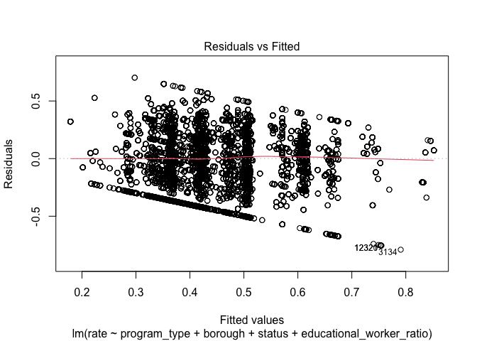

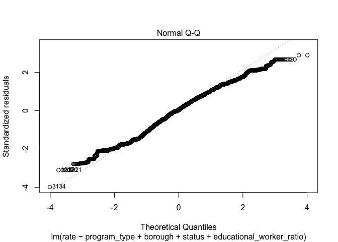

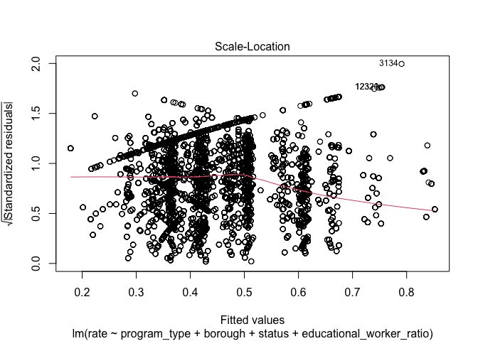

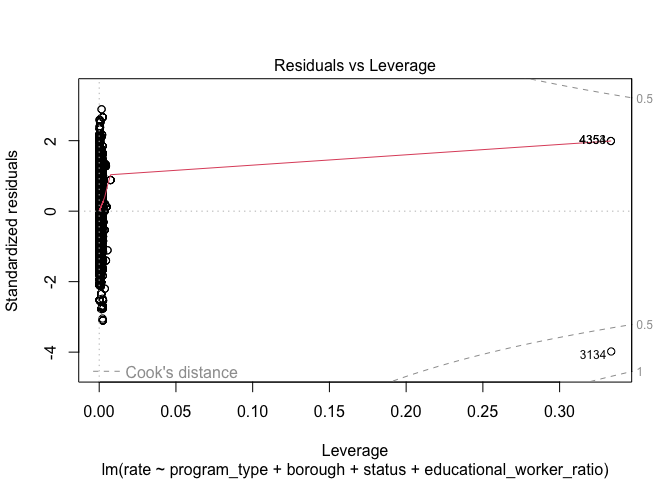

```r
# model diagnostics: Residuals vs Fitted plot, QQ plot, Scale_location, Residuals vs Leverage
plot(full_lm)
```

*Remedy:*

Therefore, to address the slight model violation issue, we firstly tried transformation to makes the data more ‘normal’. From the boxplot of two numerical variables rate and educational worker ratio we can see the latter is right skewed.

```r
# Boxblot to check the initial distribution of outcome and key predictor
center_distinct_df  %>%
par(mfrow = c(1,2))
```

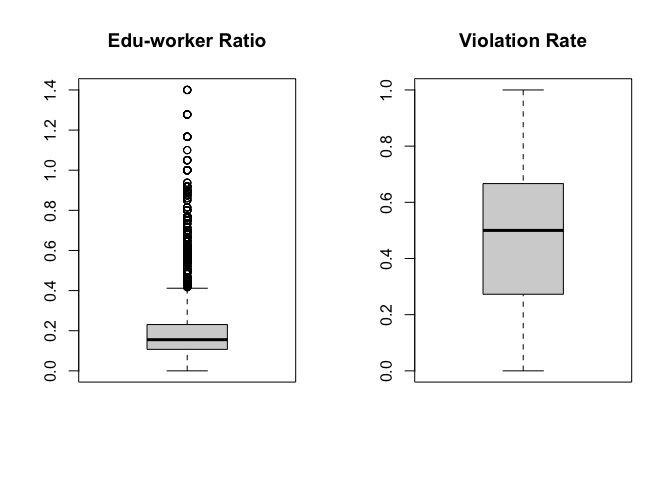

```r
boxplot(center_distinct_df$educational_worker_ratio, main = "Edu-worker Ratio")
boxplot(center_distinct_df$rate, main = "Violation Rate")
```

```r
# Square root transformation
full_lm_sqrt = center_distinct_df %>%
  lm(rate ~ program_type + borough + status + sqrt(educational_worker_ratio), data = .)
```

```r
# exclude two influential records
out_df = center_distinct_df[-c(3134),]

# fit model without influential points
full_lm_out = lm(rate ~ program_type + borough + status + educational_worker_ratio, data = out_df)

full_lm_out %>%
  broom::tidy() %>%
  knitr::kable(digit = 3)
```

| term | estimate | std.error | statistic | p.value |
| --- | --- | --- | --- | --- |
| (Intercept) | 0.865 | 0.015 | 57.407 | 0.000 |
| program_typeinfant toddler | -0.028 | 0.011 | -2.425 | 0.015 |
| program_typepreschool | -0.004 | 0.009 | -0.446 | 0.656 |
| program_typeschool age camp | 0.511 | 0.172 | 2.970 | 0.003 |
| boroughBROOKLYN | -0.245 | 0.006 | -42.838 | 0.000 |
| boroughMANHATTAN | -0.186 | 0.006 | -30.365 | 0.000 |
| boroughQUEENS | -0.104 | 0.006 | -17.315 | 0.000 |
| boroughSTATEN ISLAND | -0.323 | 0.010 | -32.285 | 0.000 |
| statusExpired-In Renewal | -0.190 | 0.012 | -15.804 | 0.000 |
| statusPermitted | -0.239 | 0.011 | -21.128 | 0.000 |
| educational_worker_ratio | -0.083 | 0.015 | -5.342 | 0.000 |

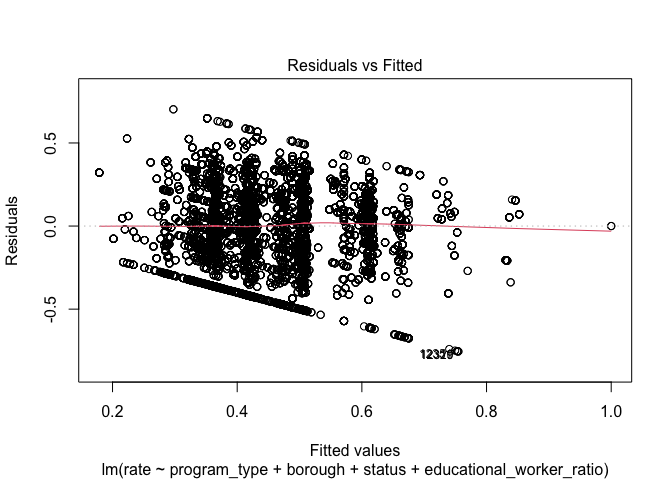

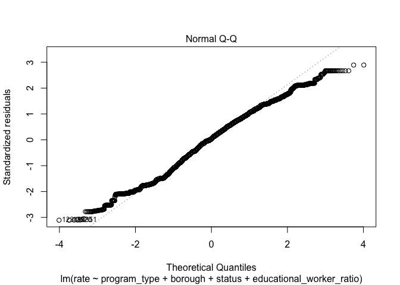

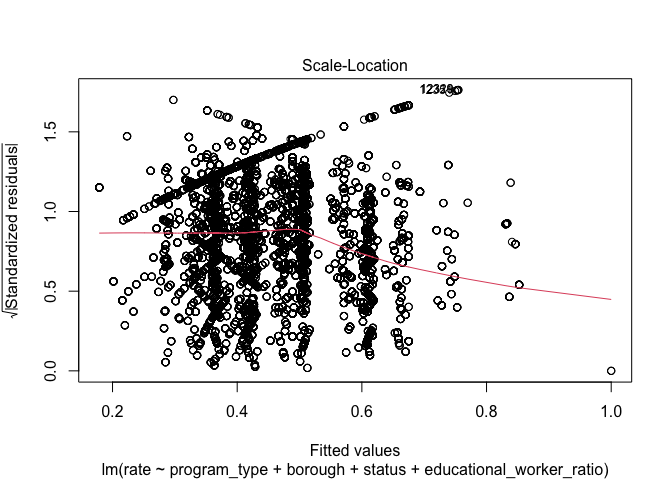

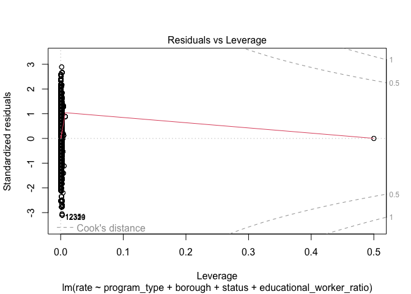

```r
# model diagnostics: Residuals vs Fitted plot, QQ plot, Scale_location, Residuals vs Leverage
plot(full_lm_out)
```

*Model validation:*

We used 5-fold cross validation to test the model performance. Based on a rule of thumb, RMSE values between 0.2 and 0.5 shows that the model can relatively predict the data accurately. Thus our model boasts good RMSE value, suggesting relatively good predictive ability.

```r
library(caret)
# Use 5-fold validation and create the training sets
train = trainControl(method = "cv", number = 5)

model_caret = train(rate ~ program_type + borough + status + educational_worker_ratio,
                   data = out_df,
                   trControl = train,
                   method = 'lm',
                   na.action = na.pass)

model_caret$finalModel
```

```
##
## Call:
## lm(formula = .outcome ~ ., data = dat)
##
## Coefficients:
##                   (Intercept)   `program_typeinfant toddler`
##                       0.86475                       -0.02760
##         program_typepreschool  `program_typeschool age camp`
##                      -0.00422                        0.51132
##               boroughBROOKLYN               boroughMANHATTAN
##                      -0.24476                       -0.18643
##                 boroughQUEENS         `boroughSTATEN ISLAND`
##                      -0.10384                       -0.32338
##    `statusExpired-In Renewal`                statusPermitted
##                      -0.18964                       -0.23890
##      educational_worker_ratio
##                      -0.08251
```

```r
print(model_caret)
```

```
## Linear Regression
##
## 16453 samples
##     4 predictor
##
## No pre-processing
## Resampling: Cross-Validated (5 fold)
## Summary of sample sizes: 13162, 13162, 13163, 13163, 13162
## Resampling results:
##
##   RMSE       Rsquared   MAE
##   0.2432694  0.1562276  0.1983364
##
## Tuning parameter 'intercept' was held constant at a value of TRUE
```

*Conclusion:*

We chose full_lm_out as our final linear model:

Interpretation:

In this model, the outcome is “rate”, indicating the violation rate for each center based on different program type. Our key predictor is the numeric variable of “educational_worker_ratio”, which is the program-specific total number of educational worker in each center, divided by the maximum capacity, based on the square footage of class and play rooms, the number of toilets and sinks, and overall estimates from the NYC Department of Buildings. Our model suggests the value of the estimated mean violation rate decreases by 0.083 for each unit increase in educational worker ratio, while holding all other variables fixed.

We also included several categorical variables into our model. Based on the output, the interpretations of coefficients estimates are as follows:

The value of the estimated mean violation rate for centers located in Brooklyn, Manhattan, Queens and Staten island are 0.245, 0.186, 0.104 and 0.323 less than centers located in Bronx, respectively, while holding other variables constant.

The value of the estimated mean violation rate for centers with licence status as expired in renewal and as permitted is 0.19 and 0.239 less than centers with licence status as active, while holding other variables constant.

The value of the estimated mean violation rate for centers implement school age camp program is 0.511 more than centers implement all age camp program, while holding other variables constant.